# How do customer demographic factors, purchase-related attributes, and service/incentive factors influence the frequency of purchases of US costumers

Author

Prasanga Paudel

**Authors**

- Prasanga Paudel$^{1}$ (ORCID: 0000-0000-1234-5678)

**Author affiliations**

1. Davis College of Agricultural Sciences & Natural Resources, Texas Tech University, Lubbock, TX, USA.

$\dagger$ Disclaimer: The opinions expressed in this article are the author’s own and don’t reflect their employer.

**Abstract**

*For business looking to create a long-lasting client relationship, boost sales, and customize a successful marketing tactics, it is highly essential to understand the underlying consumer decision making process, especially the patterns behind recurring purchases. Our study studies how customer demographics, purchase-related characteristics, incentive factors, and delivery options affect the frequency of purchase using various econometrics techniques. Based on a dataset of 1120 U.S. consumers, our analysis utilizes Ordinary Least Squares (OLS), and the two-stage least squares (2SLS) approach to make accurate explanations of purchase behavior using age, gender, income, amount spent, ratings, season, promotions, subscription, and purchase history.*

*Results from our OLS estimation revealed that age, income, previous purchases, and buying fashion related items positively and significantly influence their purchase behavior. On the other hand, males and consumers who spend more per transactions tend to purchase less frequently. Seasonal patterns are also indicated, with significantly higher purchases during spring and winter. The 2SLS approach confirmed that subscription is endogenous, and once corrected, it’s effect seems to be statistically insignificant.*

*Our findings highlight the importance of behavioral history and demographic targeting as effective source of increasing purchase frequencies. Furthermore, business should focus on personalized promotions, habit-based incentives and time-sensitive marketing campaigns to promote repeated purchase and higher revenue.*

*Keywords: customer behavior, promos, purchase frequency*

# 1 Introduction

Understanding about the dynamic consumer behaviour, specially the patterns underlying their repeated purchase is a key component to the success of any industry and business sector. Consumers sometimes act like creatures of habit, automatically repeating past behavior with little regard to current goals and valued outcomes (Wood and Neal 2009). Purchase and consumption behaviors in daily life often are repetitive and performed in customary places, leading consumers to develop habits (Ji and Wood 2007). If a business firm manages to understand the reason behind why consumers act in certain way, then it might open a gateway into more consumer persuasion and increase in revenue. Studies on the effect of demographic factors (age, gender, income) on consumption and purchase frequency have been conducted repeatedly in the past. (Saleh et al. 2013) for instance, performed a cross-sectional study analyzing the effect of gender, age, and income on consumer’s purchasing responsiveness to free product samples. Results showed that young consumers and females tend to be more responsive to such promotions and income had an insignificant effect. On the other hand, a study by (Ihsan Ullah et al. 2021) report that there is a weak or no relationship between consumer’s purchase decisions and their demographic attributes, depending on the context.

Business are always trying to come up with new ideas to generate more revenue and profit, but not all attempts are equally fruitful. Promo coupons are also one of such widely used in service establishments, even though little is known about a coupon’s impact on consumer behavior (Taylor 2001). Recent studies show that coupons and promotions can significantly influence purchase behavior, particularly in prompting repeat or earlier-than-planned purchase decisions (**Balakrishnan2020-oi?**). A recent study by (Poisson 2018) studied the effectiveness of coupons on the restaurant consumers’ purchase decision and another study by (Mishra et al. 2024) studied the impact of sales promotion on consumer buying behavior in the apparel industry. Digital era studies of online shoppers have also found that spending and purchase frequency often vary with age, income, and prior shopping patterns (Kooti et al. 2015). Similary, (Hu et al. 2008) argues that online reviews and rating affect the purchase of that product although it tends to diminish over time. One might think that purchase decisions are also influenced by the seasonal patterns of offers such as Black Friday, Cyber Monday, Summer sales, etc. Ignoring seasonal patterns in consumer’s expectations leads to biased demand estimates (Soysal and Krishnamurthi 2012). And while (Iyengar et al. 2022) report that subscription leads to increase in consumer purchases, two third of the effect is reported to be due to non-economic benefit of the subscription. On the other hand, critiques of subscription sales such as (Chen 2024) argue that effect of subscription is endogenous and it may not always increase sales as there is also a common trend of enrolling into certain subscription just because of peer influence and not much motivation to purchase.

There has been limited work combining a comprehensive set of determinants: demographic variables, purchase history, product attributes, incentives, and seasonal/contextual factors in a single model to explain purchase frequency. Following their previous studies, we want to study various consumer behaviour with detailed insights into consumer responses and shopping patterns across various demographics, locations, and product categories.

# 2 Research Objective

Our broad objective is to empirically examine the effect of different socio-economic, demographic, and product related attributes on purchase frequency. We will evaluate and try to reject/validate behavioral and loyalty theories and try to provide data-supported guidance and retail strategies. We have the following specific objectives.

• To analyze the relationship between age, gender, item category, seasonality, income with purchase frequency. • To assess whether behavioral history significantly predict current purchase frequency • To investigate if subscription or use of promo codes is associated with a higher purchase frequency.

# 3 Data source

The “Consumer Behavior and Shopping Habits” dataset that we will be using can provide us with information crucial for market analysis and tailored marketing strategies. The dataset consists of 16 variables and covers a dynamic range of consumer information from all over US. The total number of observations in our sample is 1120.

```
The dataset includes information such as:
```

```r
shopping_iv <- read_excel("../metrics-exercise/shopping_dataset.xlsx")

head(shopping_iv)
```

```
# A tibble: 6 × 16
    age gender item    item_fashion amount rating subscribed shipping discount
  <dbl> <chr>  <chr>          <dbl>  <dbl>  <dbl>      <dbl> <chr>       <dbl>
1    32 Female Sweater            1   11.4    4.5          1 Standard        0
2    41 Female Hat                1  104.     3.6          1 Express         0
3    28 Male   Hat                1  107.     3.1          1 Standard        1
4    37 Male   Hat                1  103.     3.2          1 Express         1
5    38 Female Shoes              0   78.8    4.3          1 Express         0
6    47 Male   Jeans              1   93.3    3.3          1 Standard        1
# ℹ 7 more variables: promo <dbl>, prev_purchases <dbl>, income <dbl>,
#   online_activity <dbl>, season <chr>, frequency_num <dbl>,
#   marketing_offer <dbl>
```

# 4 Methods

We will follow the strategic framework defined by (Kidane and Sharma 2016) to describe how consumer’s purchasing decision is affected by different factors such as shipping methods, services, social and individual attributes, satisfactions. We will assume that the consumer purchase decisions, specifically, consumer’s purchase frequency is defined by the following regression model.

Our objective is to explain the frequency of total purchases made in a year based on age, gender, income, promotional offers, product rating, season, previous purchase history and shipping. We will use the following linear OLS model as our base model.

$Purchase Frequency_i$ = $β_1$ + $β_2 Age_i$ + $β_3 Male_i$ + $β_4 Fashion_i$ + $β_5 Amount_i$ + $β_6 Rating_i$ + $β_7 Subscription_i$ + $β_8 Shipping_i$ + $β_9 Promo$ + $β_{10} PreviousPurchase_i$ + $β_{11} Income_i$ + $β_{12} Spring_i$ + $β_{13} Summer_i$ + $β_{14} Winter_i$ + $μ_i$

Where i represents the individual, age represents the age of the individual in years, Male is a dummy variable which equals one for male, Fashion represents a dummy variable which equals one if the purchased product is related to beauty and fashion, Amount is a continuous variable representing the amount per purchase, Rating represents a continuous variable with a value between 0 and 5, Subscription is a dummy variable that equals one if the individual has a subscription, Promo is a dummy variable that equals one if promo code was used during purchase, Previous purchase represents the total purchases made in previous year, Income is a continuous variable and the seasons are a dummy for the respective season when the purchase was done.

We have the following options for estimation: OLS, OLS (with robust SE), IV-reg

## 4.1 OLS Regression

```r
# OLS regression (biased due to endogeneity)
model_ols_sub <- lm(frequency_num ~ age + gender + item_fashion + amount + rating +
                      subscribed + shipping + promo + prev_purchases +
                      income + season,
                    data=shopping_iv)
summary(model_ols_sub)
```

```
Call:
lm(formula = frequency_num ~ age + gender + item_fashion + amount +
    rating + subscribed + shipping + promo + prev_purchases +
    income + season, data = shopping_iv)

Residuals:
    Min      1Q  Median      3Q     Max
-11.994  -2.308  -0.060   2.342  12.438

Coefficients:
                   Estimate Std. Error t value Pr(>|t|)
(Intercept)      -9.356e-02  8.949e-01  -0.105 0.916753
age               4.074e-02  1.148e-02   3.548 0.000405 ***
genderMale       -7.526e-01  2.144e-01  -3.510 0.000465 ***
item_fashion      8.490e-01  2.676e-01   3.173 0.001550 **
amount           -1.017e-02  3.647e-03  -2.788 0.005401 **
rating            1.896e-01  1.224e-01   1.548 0.121858
subscribed        1.821e+00  3.466e-01   5.254 1.78e-07 ***
shippingStandard  3.287e-01  2.138e-01   1.537 0.124545
promo             3.115e-01  2.139e-01   1.456 0.145626
prev_purchases    2.247e-01  4.952e-02   4.538 6.29e-06 ***
income            3.016e-04  7.261e-06  41.544  < 2e-16 ***
seasonSpring      8.802e-01  3.120e-01   2.821 0.004870 **
seasonSummer      1.948e-01  3.032e-01   0.642 0.520725
seasonWinter      9.679e-01  2.997e-01   3.230 0.001275 **
---
Signif. codes:  0 '***' 0.001 '**' 0.01 '*' 0.05 '.' 0.1 ' ' 1

Residual standard error: 3.565 on 1106 degrees of freedom
Multiple R-squared:  0.629, Adjusted R-squared:  0.6246
F-statistic: 144.2 on 13 and 1106 DF,  p-value: < 2.2e-16
```

## 4.2 Robust SE OLS

```r
robust_se <- coeftest(model_ols_sub, vcov = vcovHC(model_ols_sub, type = "HC1"))

print(robust_se)
```

```
t test of coefficients:

                    Estimate  Std. Error t value  Pr(>|t|)
(Intercept)      -9.3562e-02  8.9214e-01 -0.1049 0.9164957
age               4.0736e-02  1.1503e-02  3.5414 0.0004146 ***
genderMale       -7.5263e-01  2.1364e-01 -3.5228 0.0004444 ***
item_fashion      8.4903e-01  2.8056e-01  3.0261 0.0025342 **
amount           -1.0167e-02  3.4944e-03 -2.9095 0.0036925 **
rating            1.8957e-01  1.1877e-01  1.5960 0.1107704
subscribed        1.8210e+00  3.4376e-01  5.2973 1.418e-07 ***
shippingStandard  3.2868e-01  2.1312e-01  1.5423 0.1232978
promo             3.1150e-01  2.1532e-01  1.4466 0.1482814
prev_purchases    2.2475e-01  4.8462e-02  4.6376 3.945e-06 ***
income            3.0164e-04  7.3058e-06 41.2880 < 2.2e-16 ***
seasonSpring      8.8019e-01  3.1194e-01  2.8217 0.0048629 **
seasonSummer      1.9477e-01  2.9984e-01  0.6496 0.5161084
seasonWinter      9.6787e-01  3.0878e-01  3.1345 0.0017666 **
---
Signif. codes:  0 '***' 0.001 '**' 0.01 '*' 0.05 '.' 0.1 ' ' 1
```

## 4.3 Two-stage Least Squares

### 4.3.1 First stage

```r
first_stage <- lm(subscribed ~ marketing_offer + age + gender + item_fashion + amount + rating +
                       + shipping + promo + prev_purchases +
                      income + season,
                    data=shopping_iv)
summary(first_stage)
```

```
Call:
lm(formula = subscribed ~ marketing_offer + age + gender + item_fashion +
    amount + rating + +shipping + promo + prev_purchases + income +
    season, data = shopping_iv)

Residuals:
     Min       1Q   Median       3Q      Max
-0.98666 -0.02525  0.07651  0.17304  0.37246

Coefficients:
                   Estimate Std. Error t value Pr(>|t|)
(Intercept)       5.477e-01  7.237e-02   7.568 7.99e-14 ***
marketing_offer   1.891e-01  1.826e-02  10.359  < 2e-16 ***
age               5.720e-04  9.511e-04   0.601  0.54768
genderMale       -3.260e-02  1.773e-02  -1.838  0.06630 .
item_fashion      5.727e-02  2.210e-02   2.592  0.00968 **
amount           -2.589e-04  3.020e-04  -0.857  0.39150
rating            1.597e-02  1.014e-02   1.576  0.11532
shippingStandard  5.620e-03  1.774e-02   0.317  0.75141
promo            -1.703e-02  1.771e-02  -0.962  0.33648
prev_purchases    3.531e-02  4.001e-03   8.824  < 2e-16 ***
income           -1.238e-07  6.016e-07  -0.206  0.83695
seasonSpring      3.283e-02  2.583e-02   1.271  0.20412
seasonSummer      1.955e-02  2.511e-02   0.779  0.43625
seasonWinter      9.671e-03  2.483e-02   0.390  0.69697
---
Signif. codes:  0 '***' 0.001 '**' 0.01 '*' 0.05 '.' 0.1 ' ' 1

Residual standard error: 0.2953 on 1106 degrees of freedom
Multiple R-squared:  0.1493,    Adjusted R-squared:  0.1393
F-statistic: 14.93 on 13 and 1106 DF,  p-value: < 2.2e-16
```

### 4.3.2 Second stage or IV-reg

```r
# IV regression (2SLS) using marketing_offer as instrument for subscribed
model_iv_sub <- ivreg(frequency_num ~ age + gender + item_fashion + amount + rating +
                        subscribed + shipping + promo + prev_purchases +
                        income + season
                      | age + gender + item_fashion + amount + rating +
                        shipping + promo + prev_purchases +
                        income + season + marketing_offer,
                      data=shopping_iv)

summary(model_iv_sub, diagnostics=TRUE)
```

```
Call:
ivreg(formula = frequency_num ~ age + gender + item_fashion +
    amount + rating + subscribed + shipping + promo + prev_purchases +
    income + season | age + gender + item_fashion + amount +
    rating + shipping + promo + prev_purchases + income + season +
    marketing_offer, data = shopping_iv)

Residuals:
      Min        1Q    Median        3Q       Max
-11.58109  -2.39623  -0.02479   2.34100  13.07491

Coefficients:
                   Estimate Std. Error t value Pr(>|t|)
(Intercept)       1.780e+00  1.180e+00   1.508 0.131769
age               4.316e-02  1.188e-02   3.632 0.000294 ***
genderMale       -8.471e-01  2.243e-01  -3.777 0.000167 ***
item_fashion      1.030e+00  2.851e-01   3.614 0.000316 ***
amount           -1.109e-02  3.780e-03  -2.933 0.003430 **
rating            2.309e-01  1.274e-01   1.813 0.070091 .
subscribed       -1.104e+00  1.202e+00  -0.918 0.358612
shippingStandard  3.169e-01  2.207e-01   1.436 0.151188
promo             2.492e-01  2.220e-01   1.123 0.261886
prev_purchases    3.204e-01  6.340e-02   5.054 5.07e-07 ***
income            3.008e-04  7.498e-06  40.117  < 2e-16 ***
seasonSpring      1.007e+00  3.257e-01   3.092 0.002038 **
seasonSummer      2.588e-01  3.138e-01   0.825 0.409751
seasonWinter      1.017e+00  3.098e-01   3.284 0.001056 **

Diagnostic tests:
                  df1  df2 statistic p-value
Weak instruments    1 1106   107.301 < 2e-16 ***
Wu-Hausman          1 1105     6.949 0.00851 **
Sargan              0   NA        NA      NA
---
Signif. codes:  0 '***' 0.001 '**' 0.01 '*' 0.05 '.' 0.1 ' ' 1

Residual standard error: 3.678 on 1106 degrees of freedom
Multiple R-Squared: 0.6051, Adjusted R-squared: 0.6004
Wald test: 133.6 on 13 and 1106 DF,  p-value: < 2.2e-16
```

Here we model heteroskedasticity as a function of purchase amount (a reasonable proxy)

# 5 GLS

```r
# Fit a Generalized Least Squares (GLS) model

gls_model <- gls(frequency_num ~ age + gender + item_fashion + amount + rating +
                   subscribed + shipping + promo + prev_purchases +
                   income + season,
                 data = shopping_iv,
                 weights = varExp(form = ~ amount))

print(coef(summary(gls_model)), digits=4 )
```

```
                      Value Std.Error  t-value    p-value
(Intercept)      -0.0760256 8.926e-01 -0.08517  9.321e-01
age               0.0409467 1.148e-02  3.56677  3.769e-04
genderMale       -0.7467860 2.143e-01 -3.48529  5.109e-04
item_fashion      0.8258847 2.674e-01  3.08832  2.063e-03
amount           -0.0100024 3.658e-03 -2.73404  6.356e-03
rating            0.1863731 1.222e-01  1.52496  1.276e-01
subscribed        1.8146846 3.467e-01  5.23416  1.982e-07
shippingStandard  0.3204684 2.137e-01  1.49983  1.339e-01
promo             0.3088694 2.137e-01  1.44509  1.487e-01
prev_purchases    0.2232028 4.943e-02  4.51558  6.991e-06
income            0.0003015 7.245e-06 41.61876 1.437e-228
seasonSpring      0.9018986 3.116e-01  2.89457  3.871e-03
seasonSummer      0.2165234 3.030e-01  0.71467  4.750e-01
seasonWinter      0.9829011 2.992e-01  3.28462  1.053e-03
```

# 6 Model Diag

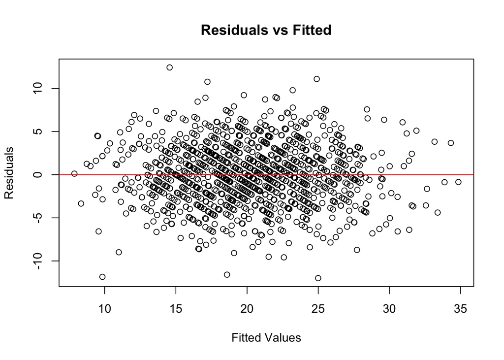

```r
# -------------------------------
# 2️⃣ Extract residuals and fitted values
residuals_ols <- residuals(model_ols_sub)
fitted_ols <- fitted(model_ols_sub)

# -------------------------------
# 3️⃣ Linearity & Homoskedasticity
# Residuals vs Fitted plot
plot(fitted_ols, residuals_ols,
     xlab="Fitted Values", ylab="Residuals",
     main="Residuals vs Fitted")
abline(h=0, col="red")
```

```r
# Breusch-Pagan test for heteroskedasticity
bptest(model_ols_sub)
```

```
    studentized Breusch-Pagan test

data:  model_ols_sub
BP = 11.576, df = 13, p-value = 0.5627
```

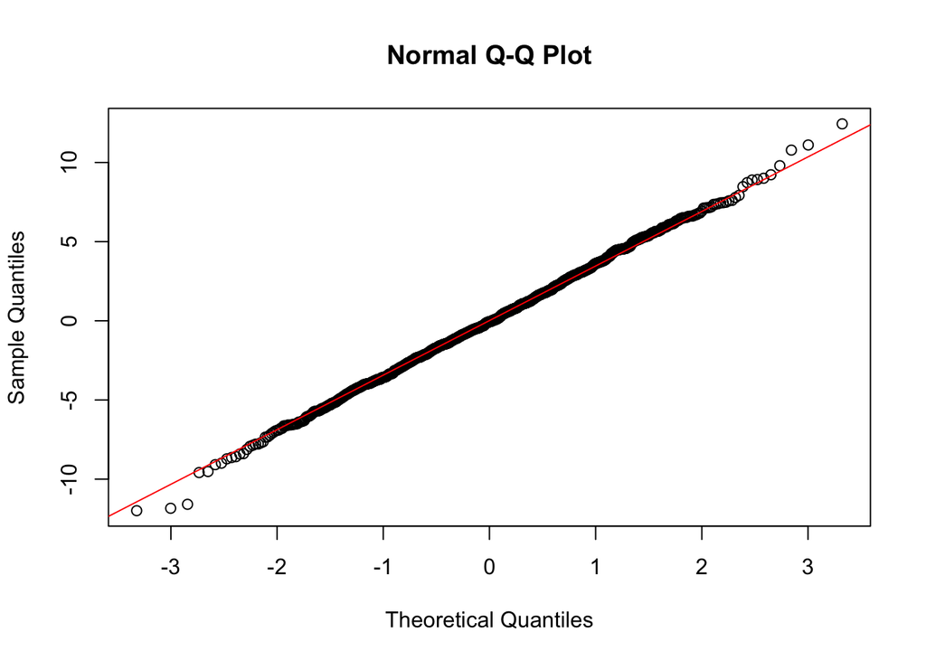

```r
# p-value > 0.05 → homoskedasticity not rejected

# -------------------------------
# 4️⃣ Normality of residuals
# QQ plot
qqnorm(residuals_ols)
qqline(residuals_ols, col="red")
```

```r
# Shapiro-Wilk test
shapiro.test(residuals_ols)
```

```
    Shapiro-Wilk normality test

data:  residuals_ols
W = 0.99915, p-value = 0.9033
```

```r
# p-value > 0.05 → residuals approx normal

# -------------------------------
# 5️⃣ Multicollinearity
vif_values <- vif(model_ols_sub)
vif_values
```

```
                   GVIF Df GVIF^(1/(2*Df))
age            1.004445  1        1.002220
gender         1.012646  1        1.006303
item_fashion   1.009607  1        1.004792
amount         1.010420  1        1.005197
rating         1.014004  1        1.006978
subscribed     1.071573  1        1.035168
shipping       1.006963  1        1.003476
promo          1.008107  1        1.004045
prev_purchases 1.064255  1        1.031627
income         1.012849  1        1.006404
season         1.021901  3        1.003617
```

```r
# VIF > 5 → moderate multicollinearity
# VIF > 10 → severe multicollinearity
```

```r
# 1️⃣ Select only numeric variables
numeric_vars <- shopping_iv %>%
  select_if(is.numeric)

# 2️⃣ Compute descriptive statistics
desc_stats <- psych::describe(numeric_vars) %>%
  as.data.frame() %>%
  select(mean, sd, min, max, median, n)

# 3️⃣ Round to 3 decimals
desc_stats <- round(desc_stats, 3)

# Add variable names as a column
desc_stats$Variable <- rownames(desc_stats)
rownames(desc_stats) <- NULL
desc_stats <- desc_stats[, c("Variable", "mean", "sd", "min", "max", "median", "n")]

print(desc_stats)
```

```
          Variable      mean        sd     min      max    median    n
1              age    34.858     9.302   18.00    67.00    34.000 1120
2     item_fashion     0.800     0.400    0.00     1.00     1.000 1120
3           amount    70.496    29.371    0.00   168.59    68.865 1120
4           rating     3.494     0.876    2.00     5.00     3.500 1120
5       subscribed     0.886     0.318    0.00     1.00     1.000 1120
6         discount     0.479     0.500    0.00     1.00     0.000 1120
7            promo     0.504     0.500    0.00     1.00     1.000 1120
8   prev_purchases     4.970     2.220    0.00    15.00     5.000 1120
9           income 49994.431 14771.454 5510.62 94898.56 49578.825 1120
10 online_activity    49.599    20.175    0.00   104.00    49.570 1120
11   frequency_num    20.217     5.818   -2.00    38.00    20.000 1120
12 marketing_offer     0.383     0.486    0.00     1.00     0.000 1120
```

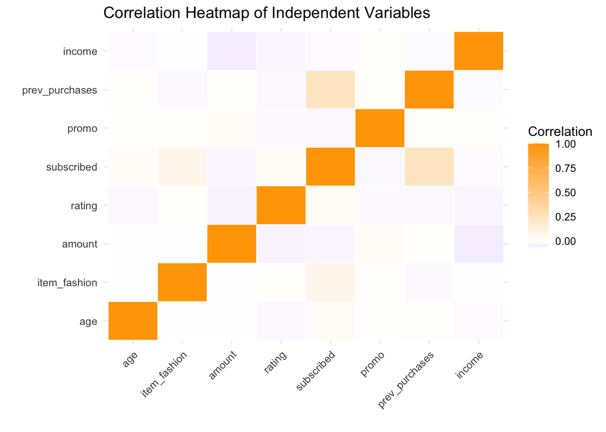

```r
# 1️⃣ Prepare numeric dataset for correlation
independent_vars <- shopping_iv %>%
  select(age, item_fashion, amount, rating,
         subscribed, promo, prev_purchases, income)  # purely numeric ones

# 2️⃣ Compute correlation matrix
corr_matrix <- round(cor(independent_vars, use = "pairwise.complete.obs"), 3)

# 3️⃣ Create a long-format dataset for plotting
corr_long <- melt(corr_matrix)
colnames(corr_long) <- c("Var1", "Var2", "Correlation")

# 4️⃣ Plot correlation heatmap
corr_plot <- ggplot(corr_long, aes(x = Var1, y = Var2, fill = Correlation)) +
  geom_tile(color = "white") +
  scale_fill_gradient2(low = "blue", mid = "white", high = "orange", midpoint = 0) +
  theme_minimal() +
  labs(title = "Correlation Heatmap of Independent Variables",
       x = "", y = "") +
  theme(axis.text.x = element_text(angle = 45, hjust = 1))

print(corr_plot)
```

## References

Chen CQ. Literature review and theoretic critique to the research of subscription sales. SSRN Electron J. 2024;

Hu N, Liu L, Zhang JJ. Do online reviews affect product sales? The role of reviewer characteristics and temporal effects. Inf Technol Manag. 2008 Sep;9(3):201–14.

Ihsan Ullah, Saleem Ullah Khan, Muhammad Idrees. Impact of demographic factors on consumer’s purchasing decision: A study on the university students of peshawar region. jbt. 2021 Nov;5(1):117–34.

Iyengar R, Park YH, Yu Q. The impact of subscription programs on customer purchases. J Mark Res. 2022 Dec;59(6):1101–19.

Ji MF, Wood W. Purchase and consumption habits: Not necessarily what you intend. J Consum Psychol. 2007 Oct;17(4):261–76.

Kidane TT, Sharma R. Factors affecting consumers’ purchasing decision through ECommerce. In: Proceedings of the 2016 international conference on industrial engineering and operations management kuala lumpur, malaysia. 2016. p. 159–65.

Kooti F, Lerman K, Aiello LM, Grbovic M, Djuric N, Radosavljevic V. Portrait of an online shopper: Understanding and predicting consumer behavior. 2015;

Mishra M, Kushwaha R, Gupta N. Impact of sales promotion on consumer buying behavior in the apparel industry. Cogent Bus Manag. 2024 Dec;11(1).

Poisson DC. The effectiveness of coupons on the restaurant consumers’ purchase decision. J Foodserv Bus Res. 2018 May;21(3):280–96.

Saleh MAH, Alothman B, Alhoshan L. Impact of gender, age and income on consumers’ purchasing responsiveness to free-product samples. Research Journal of International Studies. 2013;26:83–94.

Soysal GP, Krishnamurthi L. Demand dynamics in the seasonal goods industry: An empirical analysis. Mark Sci. 2012 Mar;31(2):293–316.

Taylor GA. Coupon response in services. J Retail. 2001 Mar;77(1):139–51.

Wood W, Neal DT. The habitual consumer. J Consum Psychol. 2009 Oct;19(4):579–92.